# Practical Lab 6 - Logistic Regression

### **Aim - The notebook aims to analyze the Iris dataset, train logistic regression models with different feature combinations, evaluate their accuracies, visualize class prediction probabilities, and recommend the most accurate model based on the analysis.**

**Import the Packages**

```python
import pandas as pd
import seaborn as sns
import matplotlib.pyplot as plt
from sklearn.datasets import load_iris
```

**Load the Dataset**

```python
# Load the iris dataset
iris = load_iris()

# Creating a DataFrame for the dataset
df = pd.DataFrame(data=iris.data, columns=iris.feature_names)
df['target'] = iris.target
```

```python
# Descriptive statistics
print(df.describe())
```

```
       sepal length (cm)  sepal width (cm)  petal length (cm)
count         150.000000        150.000000         150.000000  \
mean            5.843333          3.057333           3.758000
std             0.828066          0.435866           1.765298
min             4.300000          2.000000           1.000000
25%             5.100000          2.800000           1.600000
50%             5.800000          3.000000           4.350000
75%             6.400000          3.300000           5.100000
max             7.900000          4.400000           6.900000

       petal width (cm)      target
count        150.000000  150.000000
mean           1.199333    1.000000
std            0.762238    0.819232
min            0.100000    0.000000
25%            0.300000    0.000000
50%            1.300000    1.000000
75%            1.800000    2.000000
max            2.500000    2.000000
```

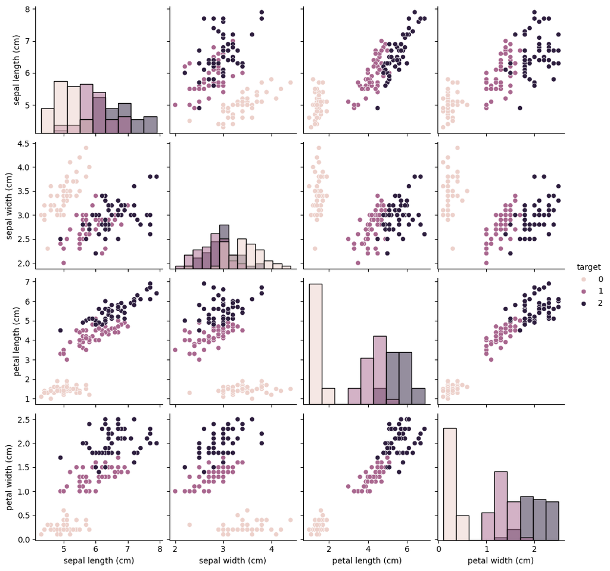

```python
# Histograms
sns.pairplot(df, hue='target', diag_kind='hist')
plt.show()
```

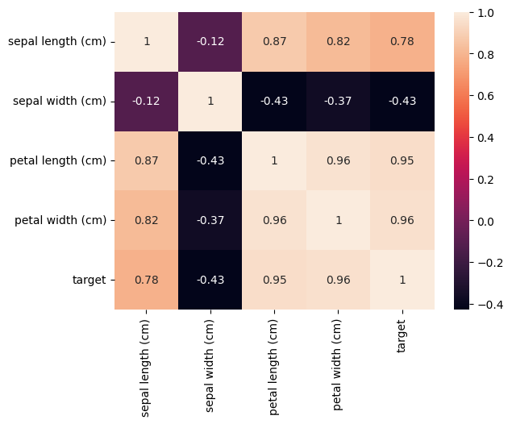

```python
# Correlation matrix
corr_matrix = df.corr()
sns.heatmap(corr_matrix, annot=True)
plt.show()
```

**Using Kaggle**

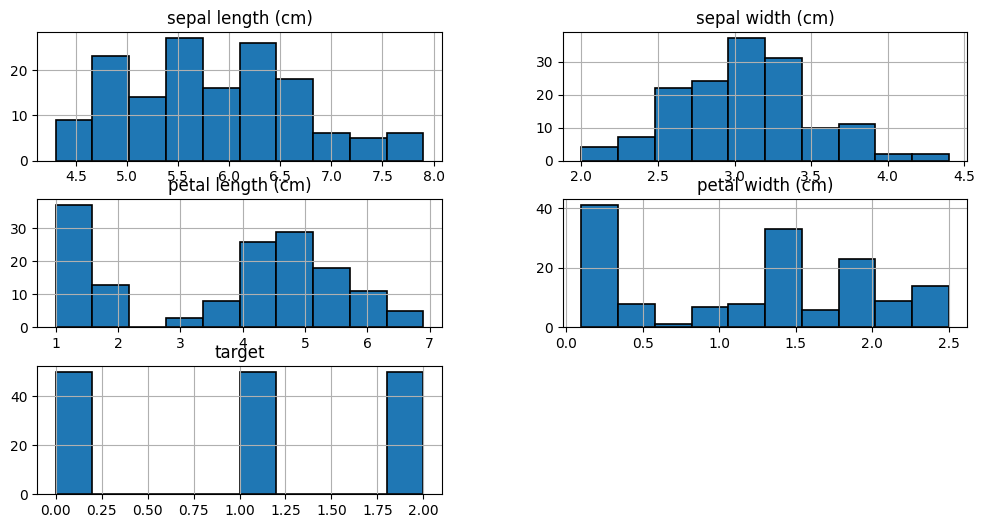

```python
df.hist(edgecolor='black', linewidth=1.2)
fig=plt.gcf()
fig.set_size_inches(12,6)
plt.show()
```

[Source Link](https://www.kaggle.com/code/ash316/ml-from-scratch-with-iris)

**Insights**

Distribution Patterns: The sepal length and width histograms exhibit roughly normal distributions, suggesting a balanced dataset. However, the petal length and width histograms show bimodal distributions, indicating the presence of distinct species or classes within the dataset.

Target Correlation: The ‘target’ histogram displays three equally tall bars, indicating a balanced number of samples for each class or species in the Iris dataset.

Feature Relationships: The petal measurements are notably more segmented than sepal measurements, implying a stronger correlation with specific Iris species and potentially serving as more significant features for classification tasks.

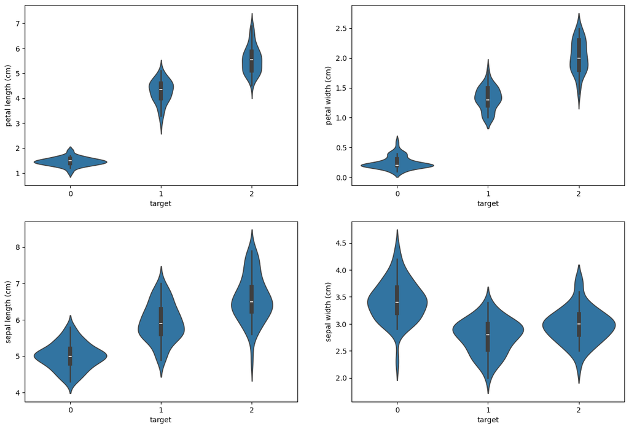

```python
plt.figure(figsize=(15,10))

plt.subplot(2,2,1)
sns.violinplot(x='target', y='petal length (cm)', data=df)

plt.subplot(2,2,2)
sns.violinplot(x='target', y='petal width (cm)', data=df)

plt.subplot(2,2,3)
sns.violinplot(x='target', y='sepal length (cm)', data=df)

plt.subplot(2,2,4)
sns.violinplot(x='target', y='sepal width (cm)', data=df)

plt.show()
```

[Source Link](https://www.kaggle.com/code/ash316/ml-from-scratch-with-iris)

**Insight**

Petal Length Variation: Class 0 (labeled as ‘0’) exhibits significantly shorter petal lengths compared to classes 1 and 2. Class 2 (labeled as ‘2’) displays a wider range in petal lengths, suggesting greater variability within this class.

Petal Width Distribution: Similar to petal length, class 0 has narrower petals. The distributions for classes 1 and 2 are broader, with class 2 having slightly wider petals on average.

Data Spread: The violin plots reveal that the data spread for class 0 is generally more compact, indicating less variability in the measurements compared to classes 1 and 2.

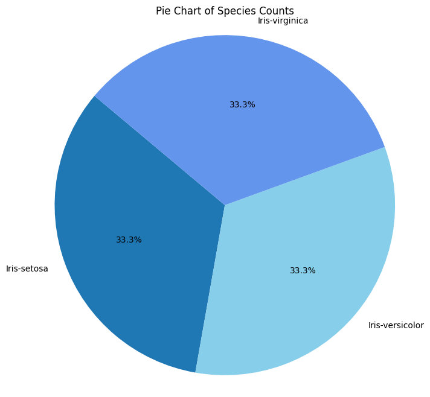

```python
# Define custom colors
custom_colors = ['#1f77b4', 'skyblue', 'cornflowerblue']

# Define data
species_counts = [50, 50, 50]
species_names = ['Iris-setosa', 'Iris-versicolor', 'Iris-virginica']

# Create pie chart
plt.figure(figsize=(8, 8))
plt.pie(species_counts, labels=species_names, colors=custom_colors, autopct='%1.1f%%', startangle=140)
plt.title('Pie Chart of Species Counts')
plt.axis('equal')  # Equal aspect ratio ensures that pie is drawn as a circle.
plt.show()
```

[Source Link](https://www.kaggle.com/code/ash316/ml-from-scratch-with-iris)

**Insight**

Equal Distribution: All three species, Iris-setosa, Iris-versicolor, and Iris-virginica, have an equal distribution in the dataset, each constituting 33.3% of the total data. This balanced distribution ensures that no species dominates the dataset, which can be advantageous for machine learning modeling to avoid bias towards any particular class.

Visualization Clarity: The pie chart effectively visualizes this equal distribution by allocating identical portions to each species. The distinct colors used for each segment make it easy to differentiate between the species.

Dataset Balance: Such an equal distribution indicates a balanced dataset, which is desirable for training machine learning models. A balanced dataset helps prevent model bias and ensures fair representation of all classes during training.

### **Define only 2 labels: virginica and non-virginica**

```python
# Redefining target labels: 1 for virginica and 0 for non-virginica
df['target'] = (df['target'] == 2).astype(int)
df.head()
```

|  | sepal length (cm) | sepal width (cm) | petal length (cm) | petal width (cm) | target |
| --- | --- | --- | --- | --- | --- |
| 0 | 5.1 | 3.5 | 1.4 | 0.2 | 0 |
| 1 | 4.9 | 3.0 | 1.4 | 0.2 | 0 |
| 2 | 4.7 | 3.2 | 1.3 | 0.2 | 0 |
| 3 | 4.6 | 3.1 | 1.5 | 0.2 | 0 |
| 4 | 5.0 | 3.6 | 1.4 | 0.2 | 0 |

### **Split the data to train, validation, test**

```python
from sklearn.model_selection import train_test_split

X = df.drop('target', axis=1)
y = df['target']

X_train, X_temp, y_train, y_temp = train_test_split(X, y, test_size=0.4, random_state=42)
X_val, X_test, y_val, y_test = train_test_split(X_temp, y_temp, test_size=0.5, random_state=42)
```

### **Logistic Regression models**

```python
from sklearn.linear_model import LogisticRegression

# Model with 1 feature
logistic_regression_model_1 = LogisticRegression(random_state=42)
logistic_regression_model_1.fit(X_train[['petal width (cm)']], y_train)

# Model with 2 features
logistic_regression_model_2 = LogisticRegression(random_state=42)
logistic_regression_model_2.fit(X_train[['petal width (cm)', 'petal length (cm)']], y_train)

# Model with 3 features
logistic_regression_model_3 = LogisticRegression(random_state=42)
logistic_regression_model_3.fit(X_train[['petal width (cm)', 'petal length (cm)', 'sepal length (cm)']], y_train)

# Model with 4 features
logistic_regression_model_4 = LogisticRegression(random_state=42)
logistic_regression_model_4.fit(X_train[['petal width (cm)', 'petal length (cm)', 'sepal length (cm)', 'sepal width (cm)']], y_train)
```

```
LogisticRegression(random_state=42)
```

### **Evaluate the model**

```python
from sklearn.metrics import accuracy_score

# Evaluate models on the test set
y_pred1 = logistic_regression_model_1.predict(X_test[['petal width (cm)']])
y_prob1 = logistic_regression_model_1.predict_proba(X_test[['petal width (cm)']])

accuracy1 = accuracy_score(y_test, y_pred1)
print("Accuracy of model with 1 feature:", accuracy1)

# print table
pd.DataFrame({'probability of predicting verginica model 1': y_prob1[:, 1].round(3),
              'actual prediction': y_pred1, 'ground truth': y_test})
```

```
Accuracy of model with 1 feature: 0.9666666666666667
```

|  | probability of predicting verginica model 1 | actual prediction | ground truth |
| --- | --- | --- | --- |
| 73 | 0.169 | 0 | 0 |
| 31 | 0.012 | 0 | 0 |
| 51 | 0.372 | 0 | 0 |
| 81 | 0.091 | 0 | 0 |
| 9 | 0.004 | 0 | 0 |
| 122 | 0.778 | 1 | 1 |
| 11 | 0.006 | 0 | 0 |
| 75 | 0.293 | 0 | 0 |
| 36 | 0.006 | 0 | 0 |
| 40 | 0.008 | 0 | 0 |
| 133 | 0.372 | 0 | 1 |
| 96 | 0.225 | 0 | 0 |
| 15 | 0.012 | 0 | 0 |
| 78 | 0.372 | 0 | 0 |
| 66 | 0.372 | 0 | 0 |
| 69 | 0.125 | 0 | 0 |
| 68 | 0.372 | 0 | 0 |
| 64 | 0.225 | 0 | 0 |
| 142 | 0.711 | 1 | 1 |
| 76 | 0.293 | 0 | 0 |
| 16 | 0.012 | 0 | 0 |
| 132 | 0.877 | 1 | 1 |
| 42 | 0.006 | 0 | 0 |
| 44 | 0.012 | 0 | 0 |
| 145 | 0.911 | 1 | 1 |
| 28 | 0.006 | 0 | 0 |
| 56 | 0.458 | 0 | 0 |
| 143 | 0.911 | 1 | 1 |
| 82 | 0.169 | 0 | 0 |
| 22 | 0.006 | 0 | 0 |

```python
# Evaluate models on the test set
y_pred2 = logistic_regression_model_2.predict(X_test[['petal width (cm)', 'petal length (cm)']])
y_prob2 = logistic_regression_model_2.predict_proba(X_test[['petal width (cm)', 'petal length (cm)']])
accuracy2 = accuracy_score(y_test, y_pred2)
print("Accuracy of model with 2 features:", accuracy2)

pd.DataFrame({'probability of predicting verginica model 2': y_prob2[:, 1].round(3),
              'actual prediction': y_pred2, 'ground truth': y_test})
```

```
Accuracy of model with 2 features: 1.0
```

|  | probability of predicting verginica model 2 | actual prediction | ground truth |
| --- | --- | --- | --- |
| 73 | 0.217 | 0 | 0 |
| 31 | 0.000 | 0 | 0 |
| 51 | 0.240 | 0 | 0 |
| 81 | 0.018 | 0 | 0 |
| 9 | 0.000 | 0 | 0 |
| 122 | 0.993 | 1 | 1 |
| 11 | 0.000 | 0 | 0 |
| 75 | 0.171 | 0 | 0 |
| 36 | 0.000 | 0 | 0 |
| 40 | 0.000 | 0 | 0 |
| 133 | 0.558 | 1 | 1 |
| 96 | 0.097 | 0 | 0 |
| 15 | 0.000 | 0 | 0 |
| 78 | 0.240 | 0 | 0 |
| 66 | 0.240 | 0 | 0 |
| 69 | 0.035 | 0 | 0 |
| 68 | 0.240 | 0 | 0 |
| 64 | 0.026 | 0 | 0 |
| 142 | 0.735 | 1 | 1 |
| 76 | 0.341 | 0 | 0 |
| 16 | 0.000 | 0 | 0 |
| 132 | 0.941 | 1 | 1 |
| 42 | 0.000 | 0 | 0 |
| 44 | 0.000 | 0 | 0 |
| 145 | 0.885 | 1 | 1 |
| 28 | 0.000 | 0 | 0 |
| 56 | 0.379 | 0 | 0 |
| 143 | 0.975 | 1 | 1 |
| 82 | 0.042 | 0 | 0 |
| 22 | 0.000 | 0 | 0 |

```python
# Evaluate models on the test set

y_pred3 = logistic_regression_model_3.predict(X_test[['petal width (cm)', 'petal length (cm)', 'sepal length (cm)']])
y_prob3 = logistic_regression_model_3.predict_proba(X_test[['petal width (cm)', 'petal length (cm)', 'sepal length (cm)']])

accuracy3 = accuracy_score(y_test, y_pred3)
print("Accuracy of model with 3 features:", accuracy3)
pd.DataFrame({'probability of predicting verginica model 3': y_prob3[:, 1].round(3),
              'actual prediction': y_pred3, 'ground truth': y_test})
```

```
Accuracy of model with 3 features: 1.0
```

|  | probability of predicting verginica model 3 | actual prediction | ground truth |
| --- | --- | --- | --- |
| 73 | 0.218 | 0 | 0 |
| 31 | 0.000 | 0 | 0 |
| 51 | 0.215 | 0 | 0 |
| 81 | 0.020 | 0 | 0 |
| 9 | 0.000 | 0 | 0 |
| 122 | 0.990 | 1 | 1 |
| 11 | 0.000 | 0 | 0 |
| 75 | 0.141 | 0 | 0 |
| 36 | 0.000 | 0 | 0 |
| 40 | 0.000 | 0 | 0 |
| 133 | 0.553 | 1 | 1 |
| 96 | 0.104 | 0 | 0 |
| 15 | 0.000 | 0 | 0 |
| 78 | 0.241 | 0 | 0 |
| 66 | 0.270 | 0 | 0 |
| 69 | 0.037 | 0 | 0 |
| 68 | 0.228 | 0 | 0 |
| 64 | 0.027 | 0 | 0 |
| 142 | 0.765 | 1 | 1 |
| 76 | 0.288 | 0 | 0 |
| 16 | 0.000 | 0 | 0 |
| 132 | 0.941 | 1 | 1 |
| 42 | 0.000 | 0 | 0 |
| 44 | 0.000 | 0 | 0 |
| 145 | 0.866 | 1 | 1 |
| 28 | 0.000 | 0 | 0 |
| 56 | 0.361 | 0 | 0 |
| 143 | 0.972 | 1 | 1 |
| 82 | 0.042 | 0 | 0 |
| 22 | 0.000 | 0 | 0 |

```python
# Evaluate models on the test set
y_pred4 = logistic_regression_model_4.predict(X_test[['petal width (cm)', 'petal length (cm)', 'sepal length (cm)', 'sepal width (cm)']])
y_prob4 = logistic_regression_model_4.predict_proba(X_test[['petal width (cm)', 'petal length (cm)', 'sepal length (cm)', 'sepal width (cm)']])

accuracy4 = accuracy_score(y_test, y_pred4)
print("Accuracy of model with 4 features:", accuracy4)
pd.DataFrame({'probability of predicting verginica model 4': y_prob4[:, 1].round(3),
              'actual prediction': y_pred4, 'ground truth': y_test})
```

```
Accuracy of model with 4 features: 1.0
```

|  | probability of predicting verginica model 4 | actual prediction | ground truth |
| --- | --- | --- | --- |
| 73 | 0.217 | 0 | 0 |
| 31 | 0.000 | 0 | 0 |
| 51 | 0.196 | 0 | 0 |
| 81 | 0.022 | 0 | 0 |
| 9 | 0.000 | 0 | 0 |
| 122 | 0.991 | 1 | 1 |
| 11 | 0.000 | 0 | 0 |
| 75 | 0.135 | 0 | 0 |
| 36 | 0.000 | 0 | 0 |
| 40 | 0.000 | 0 | 0 |
| 133 | 0.557 | 1 | 1 |
| 96 | 0.098 | 0 | 0 |
| 15 | 0.000 | 0 | 0 |
| 78 | 0.235 | 0 | 0 |
| 66 | 0.253 | 0 | 0 |
| 69 | 0.040 | 0 | 0 |
| 68 | 0.264 | 0 | 0 |
| 64 | 0.025 | 0 | 0 |
| 142 | 0.772 | 1 | 1 |
| 76 | 0.294 | 0 | 0 |
| 16 | 0.000 | 0 | 0 |
| 132 | 0.943 | 1 | 1 |
| 42 | 0.000 | 0 | 0 |
| 44 | 0.000 | 0 | 0 |
| 145 | 0.866 | 1 | 1 |
| 28 | 0.000 | 0 | 0 |
| 56 | 0.328 | 0 | 0 |
| 143 | 0.970 | 1 | 1 |
| 82 | 0.042 | 0 | 0 |
| 22 | 0.000 | 0 | 0 |

```python
# Recommend best model based on accuracy
accuracies = [accuracy1, accuracy2, accuracy3, accuracy4]
best_model_index = accuracies.index(max(accuracies)) + 1
print("Accuracies of models:")
for i, accuracy in enumerate(accuracies, start=1):
    print(f"Model {i}: {accuracy}")
print("Recommendation: Model with", best_model_index, "features has the highest accuracy.")
```

```
Accuracies of models:
Model 1: 0.9666666666666667
Model 2: 1.0
Model 3: 1.0
Model 4: 1.0
Recommendation: Model with 2 features has the highest accuracy.
```

## **Decision Boundary**

```
<function matplotlib.pyplot.show(close=None, block=None)>
```

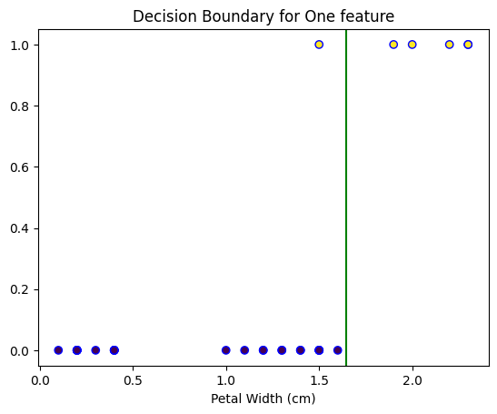

```python
import matplotlib.pyplot as plt
import numpy as np

# Plot decision boundary for model with 1 feature
X_test_feature = X_test['petal width (cm)']
decision_boundary = -logistic_regression_model_1.intercept_ / logistic_regression_model_1.coef_[0]
plt.scatter(X_test_feature, y_test, c=y_test, edgecolor='b')
plt.axvline(x=decision_boundary, color='green')
plt.xlabel('Petal Width (cm)')
plt.title('Decision Boundary for One feature')
plt.show
```

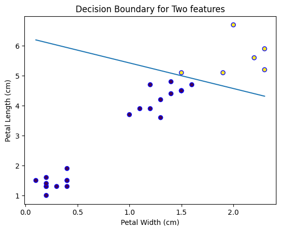

```python
# Plot decision boundary for model with 2 features
decision_boundary_x1 = np.linspace(X_test['petal width (cm)'].min(), X_test['petal width (cm)'].max(), 10)
decision_boundary_x2 = -logistic_regression_model_2.intercept_ / logistic_regression_model_2.coef_[0][1] - logistic_regression_model_2.coef_[0][0] / logistic_regression_model_2.coef_[0][1] * decision_boundary_x1
plt.scatter(X_test['petal width (cm)'], X_test['petal length (cm)'], c=y_test, edgecolor='b')
plt.plot(decision_boundary_x1, decision_boundary_x2)
plt.xlabel('Petal Width (cm)')
plt.ylabel('Petal Length (cm)')
plt.title('Decision Boundary for Two features')
plt.show()
```

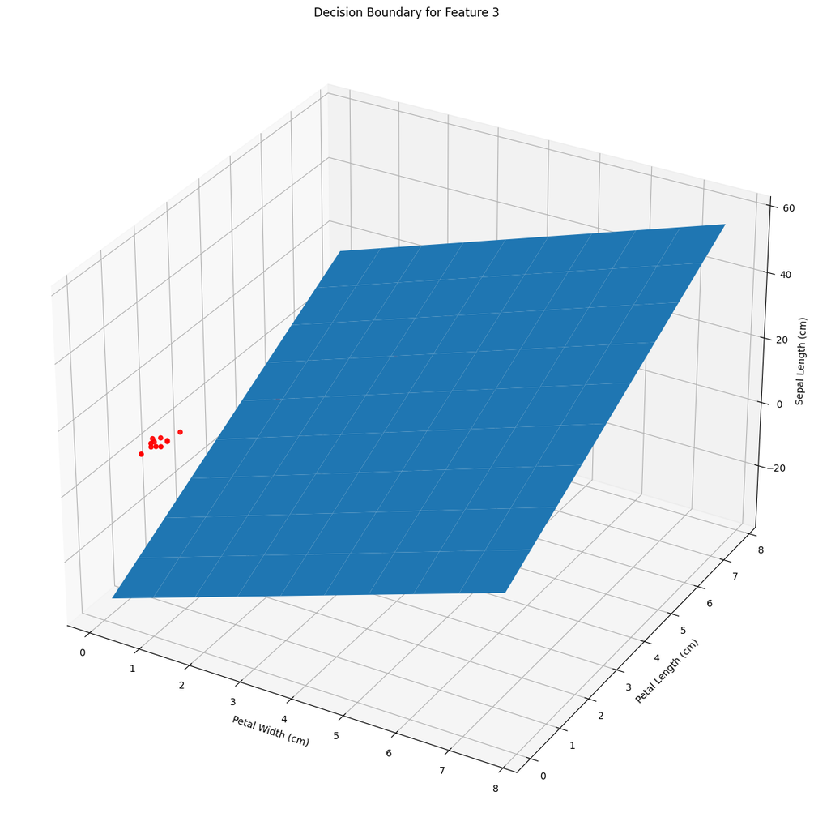

```python
min_feature_value_3 = min(X_test['petal width (cm)'].min(),X_test['petal length (cm)'].min(),X_test['sepal length (cm)'].min())
max_feature_value_3 = max(X_test['petal width (cm)'].max(), X_test['petal length (cm)'].max(),X_test['sepal length (cm)'].max())

x1, x2 = np.meshgrid(np.linspace(min_feature_value_3,max_feature_value_3, 10), np.linspace(min_feature_value_3,max_feature_value_3, 10))
decision_boundary_3 = -(logistic_regression_model_3.intercept_ / logistic_regression_model_3.coef_[0][2]) - logistic_regression_model_3.coef_[0][0] / logistic_regression_model_3.coef_[0][2] * x1 - logistic_regression_model_3.coef_[0][1] / logistic_regression_model_3.coef_[0][2] * x2


fig = plt.figure(figsize=(20,15))

# Set figure size
ax = fig.add_subplot(111, projection='3d')
ax.scatter(X_test['petal width (cm)'], X_test['petal length (cm)'], X_test['sepal length (cm)'], color='r')


ax.plot_surface(x1, x2, decision_boundary_3)
plt.title('Decision Boundary for Feature 3')
ax.set_xlabel('Petal Width (cm)')
ax.set_ylabel('Petal Length (cm)')
ax.set_zlabel('Sepal Length (cm)')
plt.show()
```

## **Best Model**

```python
best_model_index = accuracies.index(max(accuracies)) + 1
print("Recommendation: Model with", best_model_index, "features has the highest accuracy.")
```

```
Recommendation: Model with 2 features has the highest accuracy.
```

**In conclusion, the model training with less features would be preferable to the best model. and I would pick the model with the lesser number of features like model 2, based on the summary of EDA on the data sources and model prediction outcomes.**